# MasterControl QAL Analysis - EDA

Rob Sheehy

2026-02-22

# Business Context

MasterControl wants to improve their Mx (Manufacturing) product performance. Right now Mx converts at 12.7% while Qx (Quality) converts at 19.7%. The goal is to figure out which industries, company sizes, and buyer personas actually convert for Mx so they can focus their outbound efforts better.

# Chunk 1: Load and Basic Setup

```r
library(tidyverse)
library(lubridate)
library(scales)
library(knitr)

# Load data
df <- read_csv("QAL Performance for MSBA.csv", show_col_types = FALSE)

# Quick check
cat("Loaded", nrow(df), "leads from",
    min(df$`qal cohort date`), "to", max(df$`qal cohort date`), "\n")
```

```
## Loaded 16815 leads from 19723 to 20458
```

**Notes - Initial Load**

Data looks clean on import. Need to check for: - Missing values (I know there’s ~40% missing on some fields) - How the outcome variable is coded - Whether dates parsed correctly

# Chunk 2: Target Variable Check

```r
# What outcomes do we have?
outcome_counts <- df %>%
  count(`next_stage__c`, name = "n") %>%
  mutate(pct = round(100 * n / sum(n), 1)) %>%
  arrange(desc(n))

kable(outcome_counts, caption = "Lead Outcomes Distribution")
```

Lead Outcomes Distribution

| next_stage__c | n | pct |
| --- | --- | --- |
| Recycled | 12067 | 71.8 |
| SQL | 2718 | 16.2 |
| Exclude | 1227 | 7.3 |
| NA | 483 | 2.9 |
| SQO | 254 | 1.5 |
| Won | 42 | 0.2 |
| Lost | 12 | 0.1 |
| MQL | 10 | 0.1 |
| INQ | 2 | 0.0 |

```r
# Calculate baseline SQL conversion
baseline <- df %>%
  summarise(
    total = n(),
    sql = sum(`next_stage__c` == "SQL", na.rm = TRUE),
    rate = round(sql / total * 100, 2)
  )

cat("\nBaseline SQL conversion rate:", baseline$rate, "%\n")
```

```
##
## Baseline SQL conversion rate: 16.16 %
```

**Notes - Target Variable**

Key findings: - 71.8% of leads are Recycled - that’s the majority outcome - Only 16.2% make it to SQL - Just 42 Won deals (0.2%)

Baseline SQL conversion rate: 16.16%

This tells me most leads don’t progress, which aligns with MasterControl’s “change is hard” objection. The 12.7% Mx rate is about 3.5 percentage points below baseline - a 20%+ relative gap. Need to find where Mx performs at or above this 16% mark.

Also 2.9% have missing outcomes - will exclude those since I can’t classify them.

# Chunk 3: Missing Data Assessment

```r
# Calculate missingness
missing_summary <- df %>%
  summarise(across(everything(), ~sum(is.na(.)))) %>%
  pivot_longer(everything(), names_to = "variable", values_to = "n_missing") %>%
  mutate(
    total = nrow(df),
    pct_missing = round(100 * n_missing / total, 1)
  ) %>%
  filter(n_missing > 0) %>%
  arrange(desc(pct_missing))

kable(missing_summary, caption = "Fields with Missing Data")
```

Fields with Missing Data

| variable | n_missing | total | pct_missing |
| --- | --- | --- | --- |
| acct primary site function | 6877 | 16815 | 40.9 |
| acct manufacturing model | 6875 | 16815 | 40.9 |
| contact/lead title | 6408 | 16815 | 38.1 |
| next_stage__c | 483 | 16815 | 2.9 |
| acct territory rollup | 133 | 16815 | 0.8 |
| acct target industry | 45 | 16815 | 0.3 |
| acct tier rollup | 45 | 16815 | 0.3 |
| contact/lead id | 3 | 16815 | 0.0 |

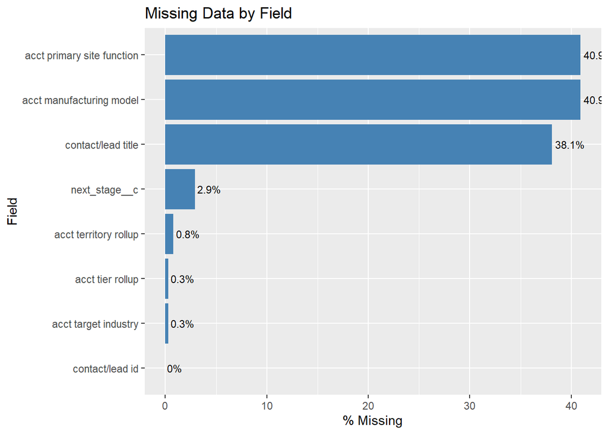

```r
# Visualize
missing_summary %>%
  ggplot(aes(x = reorder(variable, pct_missing), y = pct_missing)) +
  geom_col(fill = "steelblue") +
  coord_flip() +
  labs(title = "Missing Data by Field",
       x = "Field", y = "% Missing") +
  geom_text(aes(label = paste0(pct_missing, "%")), hjust = -0.1, size = 3)
```

**Notes - Missing Data Challenge**

The big issue: 40.9% missing for manufacturing model and site function. That’s almost half the dataset - AI web scraping (Tably AI) failed on these fields.

Also 38.1% missing job titles.

**What this means:**

Any segmentation by manufacturing model or site function only covers 59% of the data. Need to decide: exclude the missing 41%, create “Unknown” category, or try to impute?

For now keeping them but will flag when missingness is high. Need to check if missing data is random or patterned - tells me if it’s safe to exclude.

Good news: industry (0.3% missing), tier (0.3%), and territory (0.8%) are nearly complete. Can do basic segmentation with those.

**Bottom line:** This 40% missing will limit my manufacturing model analysis throughout the EDA.